# Indice di fiducia dei cluster RFID

Come si calcola e perché è semplice ed efficace

Autore/Autrice

Aldo Caumo

Data di Pubblicazione

28/10/2026

L’indice di fiducia è un voto da 0 a 1 che dice quanto ci si può fidare di un cluster di letture RFID. Si ottiene sommando sei verifiche, ognuna con un punteggio da 0 a 1 e un peso fisso: ogni punto perso ha una causa che si legge direttamente nei dati.

*Numeri e grafici di questo report sono calcolati alla compilazione con le funzioni del pacchetto, sul dataset di esempio dell’app, anno 2025: 263 cluster di 238 contenitori.*

## Come si calcola

Per ogni cluster si risponde a sei domande. Ogni risposta è un punteggio da 0 a 1. L’indice è la somma dei sei punteggi, ciascuno moltiplicato per il proprio peso, arrotondata a due decimali.

fiducia = 0,25 × p<sub>letture</sub> + 0,25 × p<sub>compattezza</sub> + 0,15 × p<sub>censimento</sub> + 0,15 × p<sub>stabilità</sub> + 0,10 × p<sub>raccolte</sub> + 0,10 × p<sub>unicità</sub>

I pesi sommano a 1: un cluster che supera tutte le verifiche vale 1, uno che le fallisce tutte vale 0.

| Verifica | Domanda | Peso | Come si assegna il punteggio |
| --- | --- | --- | --- |
| Letture | Il cluster ha abbastanza letture? | 0,25 | Letture del cluster divise per 10, con massimo 1. Cinque letture valgono 0,5 |
| Compattezza | Le letture cadono tutte nello stesso punto? | 0,25 | 1 fino a 50 m di dispersione, 0 da 500 m in su. In mezzo scende su scala logaritmica: 158 m valgono 0,5 |
| Censimento | Il contenitore è a database? | 0,15 | 1 se presente, 0 se non presente |
| Stabilità | Il servizio è sempre lo stesso? | 0,15 | Censito: 1 se il servizio non è mai cambiato, 0,5 se è cambiato. Non censito: 0 se il giro prevalente copre fino al 50% delle letture, 1 dall’80%, proporzionale in mezzo |
| Raccolte | Le raccolte osservate corrispondono a quelle previste? | 0,10 | Il valore minore diviso per il maggiore, tra raccolte presunte e previste. 0,5 se le previste non sono note |
| Unicità | Il contenitore è stato letto in un solo luogo? | 0,10 | Quota delle letture del contenitore che cadono in questo cluster |

La dispersione è il 90° percentile della distanza delle letture dal baricentro del cluster. Le raccolte presunte sono le letture del cluster riportate a un anno.

## Cinque esempi svolti

La parte vuota di ogni colonna è il punto perso, e la colonna dice dove.

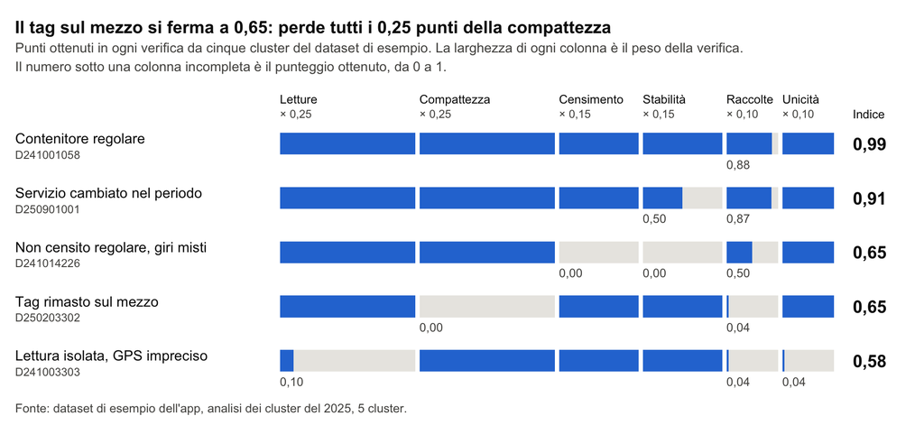

## Perché è semplice da capire

L’indice si rifà a mano: sei moltiplicazioni e una somma.

- **Sei domande concrete.** Ogni verifica è una domanda che un operatore si farebbe davanti al bidone: quante volte è stato letto, sempre nello stesso punto, è a database.
- **Un conto che sta in una riga.** Per il contenitore regolare dell’esempio: 0,25 × 1,00 + 0,25 × 1,00 + 0,15 × 1,00 + 0,15 × 1,00 + 0,10 × 0,88 + 0,10 × 1,00 = 0,99. In un foglio di calcolo è una formula sola.
- **Ogni punto perso ha un nome.** I contributi si sommano, quindi la distanza da 1 si divide esattamente tra le verifiche. Il tag rimasto sul mezzo perde 0,25 per la compattezza e 0,10 per le raccolte: basta questo a spiegare il suo 0,65.
- **Le stesse soglie della classificazione.** 50 m, 500 m e 80% sono le soglie già usate dagli indicatori. Non c’è un secondo insieme di regole da imparare.
- **Scala fissa.** L’indice va sempre da 0 a 1, qualunque siano il numero di letture e la lunghezza del periodo. Due analisi diverse restano confrontabili.
- **Nessun modello da addestrare.** Pesi e soglie sono pochi numeri scritti in chiaro. Chi non condivide un peso lo cambia e vede subito l’effetto.

La somma pesata è stata preferita a due alternative più sofisticate.

| Metodo | Si spiega in una frase | Richiede controlli sul campo già raccolti | Con un dato mancante |
| --- | --- | --- | --- |
| Somma pesata, quella adottata | Sì: sei verifiche, ognuna con il suo peso | No | Ne risente solo quella verifica, le altre restano |
| Prodotto dei punteggi | In parte: un solo zero azzera tutto | No | L’indice si azzera o non si calcola |
| Modello statistico addestrato | No: i coefficienti non si leggono | Sì, e oggi non esistono | Dipende dal modello |

## Perché è efficace

Sul dataset di esempio l’indice separa i cluster regolari dagli altri, aggiunge informazione all’indicatore e non dipende dal valore esatto dei pesi.

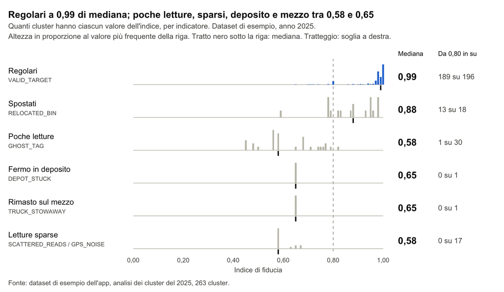

- **Dice qualcosa in più dell’indicatore.** I 7 cluster regolari sotto 0,80 sono tutti contenitori non censiti. L’indicatore li dà al loro posto. L’indice segnala che manca l’anagrafica e li ordina da 0,65 a 0,78, secondo quanto concordano i giri che li leggono.
- **Ordina dentro la stessa categoria.** Per il bidone spostato di circa 20 km, il luogo con 1 lettura vale 0,59 e quello con 8 letture vale 0,93. L’indice dice quale delle due posizioni è solida.
- **Regge al variare dei pesi.** In 5.000 prove ogni peso è stato cambiato a caso, tra la metà e una volta e mezza il suo valore. L’ordine dei cluster è rimasto quasi identico: correlazione di rango 0,998 in mediana, mai sotto 0,98. Con sei pesi uguali è 0,99.
- **Nessuna verifica decide da sola.** Il peso massimo è 0,25. Un solo dato sbagliato non affossa un cluster e un solo dato buono non lo salva.
- **Ogni verifica premia in una sola direzione.** Un cluster più compatto, con il servizio più stabile o più vicino alle raccolte previste ha sempre un indice uguale o più alto. Non ci sono inversioni da spiegare.
- **Si appoggia a ciò che i mezzi misurano.** Letture, compattezza e unicità valgono il 60% dell’indice e vengono dai lettori e dal GPS. Il resto dipende dall’anagrafica.
- **Indica cosa fare.** La verifica con il punteggio più basso suggerisce l’azione: censire il contenitore, controllare la posizione, rivedere il calendario di raccolta.

## Cosa resta da verificare

L’evidenza di oggi viene da dati simulati: la conferma definitiva richiede un confronto con controlli sul campo.

- **Va letto insieme all’indicatore.** L’indice misura quanto è solido il dato, l’indicatore dice che cosa è successo. Un tag fermo in deposito o rimasto sul mezzo ha molte letture e resta a 0,65: non è un contenitore regolare, e a dirlo è l’indicatore.
- **Dati di prova.** I numeri di questo documento vengono dal dataset di esempio dell’app, costruito a tavolino con casi noti. Sui dati reali le distribuzioni saranno meno nette.
- **Verifica sul campo.** Il passo che manca è controllare di persona un campione di cluster con indice alto e uno con indice basso, e contare quante volte l’indice aveva ragione.
- **Parentela con l’indicatore.** Indice e indicatore usano entrambi letture e dispersione, quindi una parte del loro accordo è attesa. L’informazione in più viene da censimento, stabilità del servizio e raccolte.
- **Pesi scelti a giudizio.** I pesi riflettono una valutazione, non una stima sui dati. La prova di stabilità mostra che il risultato non dipende dal loro valore esatto.
- **Non è una probabilità.** Un indice di 0,80 non significa 80% di probabilità che il bidone sia al suo posto. Serve a ordinare i cluster e a capire cosa manca a ciascuno.